# Human GC content

### Generate lists of human genes biased by the number of GCs for the genes.

Use a gene info file derived from a gtf file from Ensembl containing all the genes and GCs in the human genome.

To check whether any gene ontology or other functional categories were associated with high or low GC content, lists of genes were generated biased by GC content.

Preliminary work looking at GC biases using intervals over the whole range of GC content in the genome only identified categories using genes with high or low GC content, not the intermediate ranges, so we’re focusing on the ends of the distribution.

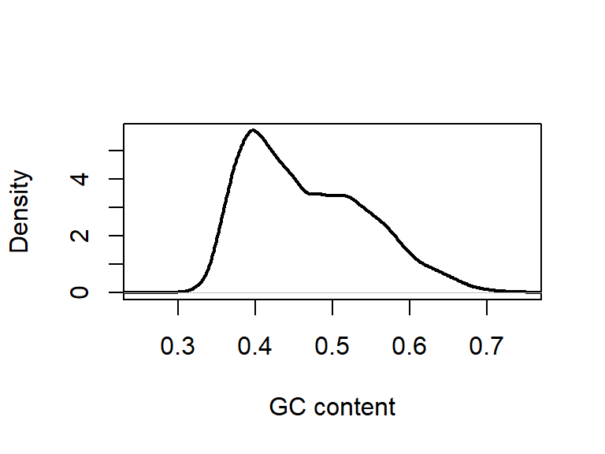

## Selecting GC thresholds

[output not shown]

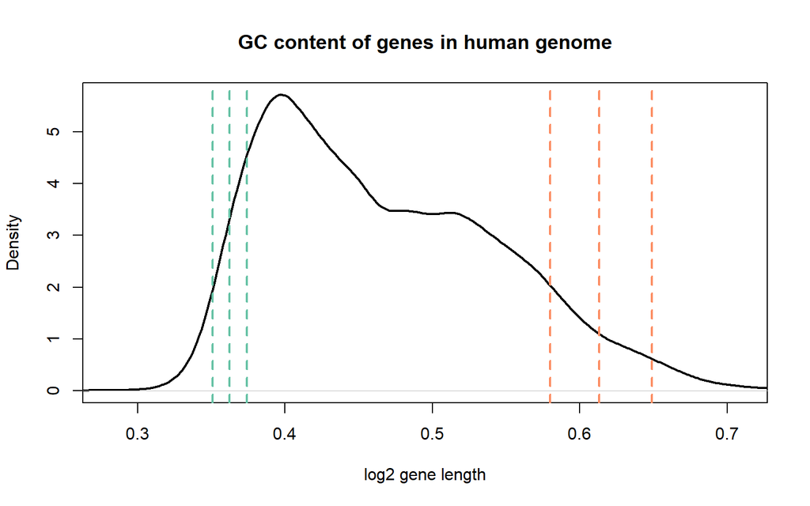

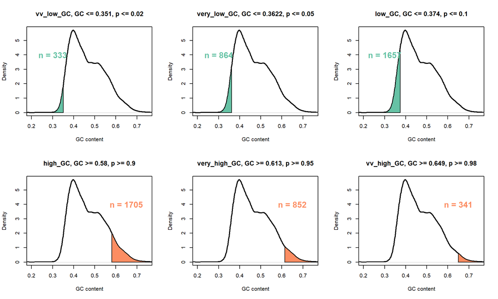

## Generating the biased gene lists and running them through functional enrichment analysis

1. The thresholds are used to filter the set of genes.
2. 200 genes are then randomly selected from the filtered set.
3. These are run through a functional enrichment analysis and the results are recorded.

The steps are repeated 100 times for each threshold.

The helper functions and the GO analysis code should be extracted

| bias_category | n |
| --- | --- |
| high_GC | 22 |
| low_GC | 32 |
| very_high_GC | 68 |
| very_low_GC | 74 |
| vv_high_GC | 45 |
| vv_low_GC | 98 |

The table shows the number of functional enrichment analyses that returned 1 or more significantly enriched categories from the 100 that were run.

## Identified categories

The number of times that a functional category was identified from the 100 times that the analysis was run for each bias category. The table contains every functional category that appeared once or more in any of the bias categories.

| GO_category | vv_low_GC | very_low_GC | low_GC | high_GC | very_high_GC | vv_high_GC |
| --- | --- | --- | --- | --- | --- | --- |
| TNFSF1%IOB%TNFSF1 | 0 | 0 | 0 | 0 | 2 | 0 |
| NABA_MATRISOME_ASSOCIATED%MSIGDB_C2%NABA_MATRISOME_ASSOCIATED | 1 | 0 | 0 | 0 | 0 | 0 |
| PID_HNF3B_PATHWAY%MSIGDB_C2%PID_HNF3B_PATHWAY | 0 | 0 | 0 | 0 | 4 | 0 |
| PID_LYMPH_ANGIOGENESIS_PATHWAY%MSIGDB_C2%PID_LYMPH_ANGIOGENESIS_PATHWAY | 0 | 1 | 0 | 0 | 0 | 0 |
| PID_P38_MK2_PATHWAY%MSIGDB_C2%PID_P38_MK2_PATHWAY | 0 | 0 | 0 | 0 | 2 | 0 |
| PID_CXCR3_PATHWAY%MSIGDB_C2%PID_CXCR3_PATHWAY | 0 | 0 | 0 | 0 | 1 | 0 |
| BIOCARTA_GCR_PATHWAY%MSIGDB_C2%BIOCARTA_GCR_PATHWAY | 0 | 1 | 0 | 0 | 0 | 0 |
| NABA_ECM_AFFILIATED%MSIGDB_C2%NABA_ECM_AFFILIATED | 0 | 0 | 0 | 0 | 0 | 2 |
| BIOCARTA_ALK_PATHWAY%MSIGDB_C2%BIOCARTA_ALK_PATHWAY | 0 | 2 | 0 | 0 | 0 | 0 |
| SIG_CD40PATHWAYMAP%MSIGDB_C2%SIG_CD40PATHWAYMAP | 0 | 0 | 0 | 0 | 1 | 0 |

[output cut: 1159 more lines]

In total, 1169 functional categories appeared at least once.

## Filter Categories

We don’t want categories that only appeared a handful of times so we’ll use an arbitrary value of 20 as a threshold.

| GO_category | vv_low_GC | very_low_GC | low_GC | high_GC | very_high_GC | vv_high_GC |
| --- | --- | --- | --- | --- | --- | --- |
| DIGESTION OF DIETARY CARBOHYDRATE%REACTOME DATABASE ID RELEASE 70%189085 | 68 | 4 | 2 | 0 | 0 | 0 |
| GLUCURONIDATION%REACTOME%R-HSA-156588.3 | 53 | 16 | 0 | 0 | 0 | 0 |
| OLFACTORY SIGNALING PATHWAY%REACTOME DATABASE ID RELEASE 70%381753 | 80 | 42 | 11 | 0 | 0 | 0 |
| PHASE II - CONJUGATION OF COMPOUNDS%REACTOME%R-HSA-156580.2 | 31 | 5 | 0 | 0 | 0 | 0 |
| SIGNALING BY GPCR%REACTOME DATABASE ID RELEASE 70%372790 | 81 | 14 | 4 | 0 | 0 | 0 |
| GPCR DOWNSTREAM SIGNALLING%REACTOME%R-HSA-388396.6 | 83 | 26 | 5 | 0 | 0 | 0 |
| DIGESTION AND ABSORPTION%REACTOME DATABASE ID RELEASE 70%8963743 | 38 | 0 | 0 | 0 | 0 | 0 |
| G ALPHA (S) SIGNALLING EVENTS%REACTOME DATABASE ID RELEASE 70%418555 | 88 | 35 | 7 | 0 | 0 | 0 |
| DIGESTION%REACTOME DATABASE ID RELEASE 70%8935690 | 43 | 2 | 1 | 0 | 0 | 0 |
| GLUCURONIDATION%WIKIPATHWAYS_20190910%WP698%HOMO SAPIENS | 53 | 14 | 0 | 0 | 0 | 0 |

[output cut: 36 more lines]

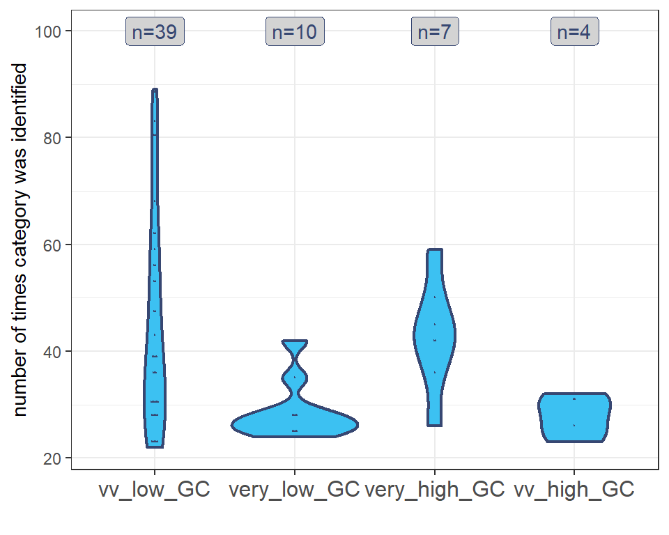

## Deduplicate

There are a few overlapping categories. The duplicate terms will be removed from the more stringent categories.

Laura Biggins

2020-01-16